# Final_Poster

2025-05-10

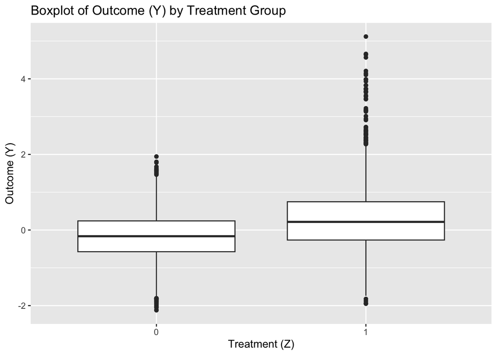

```r
# Load required libraries
library(tidyverse)  # For data wrangling and ggplot2
library(ggplot2)    # For visualization (included in tidyverse)

# Load the dataset
data <- read.csv("data.csv")

# Boxplot of outcome (Y) by treatment (Z)
# This helps compare the median, spread, and potential outliers between treated and control groups
data %>%
  ggplot(aes(x = as.factor(z), y = y)) +
  geom_boxplot() +
  labs(title = "Boxplot of Outcome (Y) by Treatment Group",
       x = "Treatment (Z)", y = "Outcome (Y)")
```

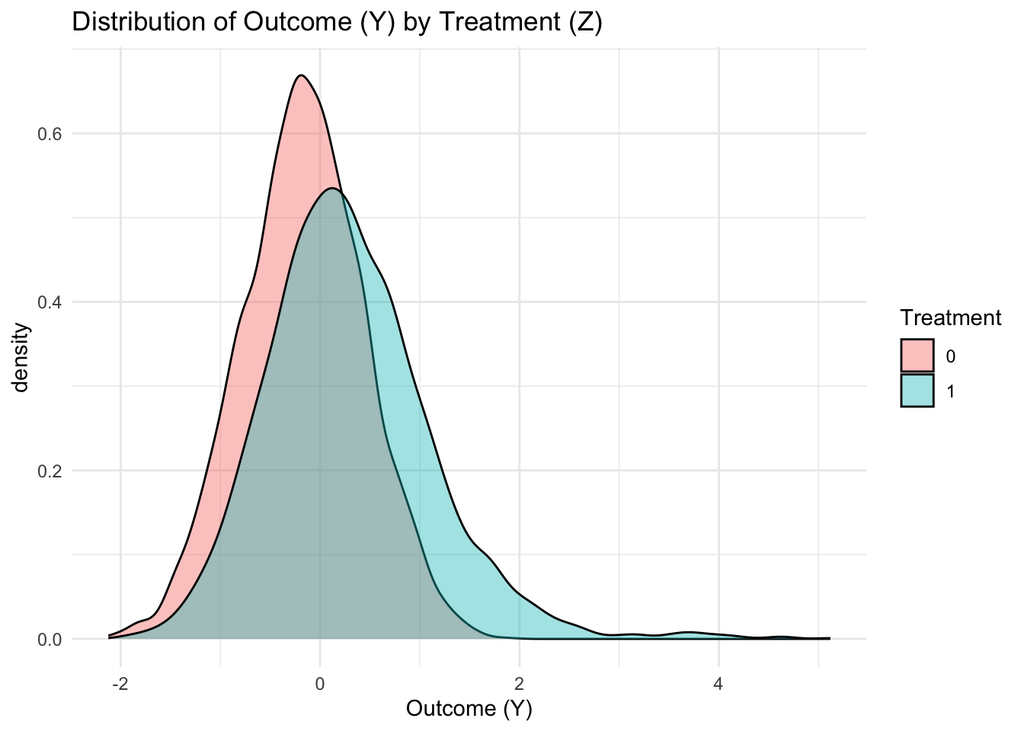

```r
# Density plot of outcome (Y) by treatment (Z)
# This provides a smooth view of the distribution of Y for treated vs control groups
ggplot(data, aes(x = y, fill = as.factor(z))) +
  geom_density(alpha = 0.4) +  # alpha controls transparency
  labs(title = "Distribution of Outcome (Y) by Treatment (Z)",
       x = "Outcome (Y)", fill = "Treatment") +
  theme_minimal()  # cleaner theme for plots
```

Rightward shift in Treated group: The distribution for Z = 1 (treated group) is slightly shifted to the right, indicating higher values of Y on average. This suggests a positive effect of the treatment on the outcome. Visually, the treated group (z = 1) seems to have a higher median outcome and slightly greater spread than the control group This suggests a positive association between receiving the intervention and higher achievement — a good initial sign that the treatment might be effective.